# Frequency of a DNA motif in a set of sequences

Jim Zhang

2019-09-09

This analysis reports of the frequency and location of a DNA motif in a given set of sequences, and compares the observed frequency to expected frequency.

- The motif is searched in each sequence to report its occurances location in the sequence.
- For each sequence, the observed frequency is compared to expected frequency, which is calculated based on overall base frequency of the sequence.
- Over- or under-representation of the motif in each sequence is calculated as the ratio of its observed frequency over expected frequency, and tested by Poisson test.
- Overall over- or under-representation of the motif in all sequences is summarized.
- Overall location of motif within all sequences is summarized.

*[Go to project home](https://github.com/zhezhangsh/RoCA)*

# 1 Description

## 1.1 Project

RoCA for motif frequency in a set of DNA sequences

## 1.2 Analysis

*[Go to project home](https://github.com/zhezhangsh/RoCA)*

# 2 Results

## 2.1 DNA sequences

**Table 1.** Length and GC content of **81** DNA sequences.

|  | Min. | 1st Qu. | Median | Mean | 3rd Qu. | Max. |
| --- | --- | --- | --- | --- | --- | --- |
| Length (bp) | 201.00 | 201.00 | 201.00 | 201.00 | 201.00 | 201.00 |
| GC (%) | 25.87 | 46.27 | 56.22 | 56.88 | 69.65 | 86.57 |

*[Go to project home](https://github.com/zhezhangsh/RoCA)*

## 2.2 Motif frequency in sequences

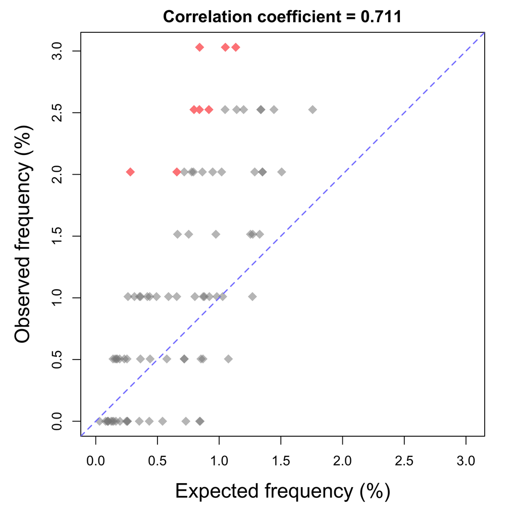

**Figure 1.** Expected vs. observed frequency of motif **AAAG** in sequences. Each diamond represents one sequence and its expected frequency of the motif is calculated according to its base frequency. Both of the original and reverse-complemented sequence of the motif were counted Difference between expected and observed frequencies was tested by Poisson test and the sequences with p value less than 0.05 are highlighted.

## 2.3 Motif location in sequences

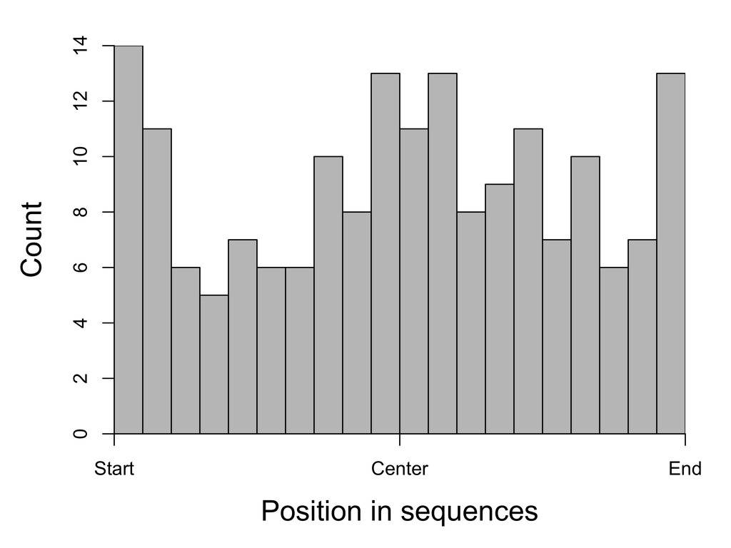

**Figure 2.** Distribution of matches to motif within the sequences, all of them combined. Sequence length was adjusted so the positions are relative.

# 3 Appendix

Check out the **[RoCA home page](http://zhezhangsh.github.io/RoCA)** for more information.

## 3.1 Reproduce this report

To reproduce this report:

1. Find the data analysis template you want to use and an example of its pairing YAML file [here](https://github.com/zhezhangsh/RoCA/wiki/Templates-and-examples) and download the YAML example to your working directory
2. To generate a new report using your own input data and parameter, edit the following items in the YAML file:
   - *output* : where you want to put the output files
   - *home* : the URL if you have a home page for your project
   - *analyst* : your name
   - *description* : background information about your project, analysis, etc.
   - *input* : where are your input data, read instruction for preparing them
   - *parameter* : parameters for this analysis; read instruction about how to prepare input data
3. Run the code below within *R Console* or *RStudio*, preferablly with a new R session:

```r
if (!require(devtools)) { install.packages('devtools'); require(devtools); }
if (!require(RCurl)) { install.packages('RCurl'); require(RCurl); }
if (!require(RoCA)) { install_github('zhezhangsh/RoCAR'); require(RoCA); }

CreateReport(filename.yaml);  # filename.yaml is the YAML file you just downloaded and edited
```

If there is no complaint, go to the *output* folder and open the *index.html* file to view report.

*[Go to project home](https://github.com/zhezhangsh/RoCA)*

*END OF DOCUMENT*